# General(ized) Linear Models: Partitioning Variance

## GLMs and Variance

> How much of the variation in the outcome variable is explained by the predictor variables?

[figure not shown]

## Multiple Regression Makes a Composite Variable

- Linear combination of predictor variables that is maximally correlated with outcome variable
- How well can you predict the outcome by the set of predictor variables?
  - correlation of y with \(\hat{y}\)
  - \(R^{2}\) = squared correlation coefficient of y with \(\hat{y}\)

## Milk Energy

```r
milk <- read_excel("../data/Milk.xlsx", na = "NA")
M <- milk %>%
  select(species, kcal.per.g, mass, neocortex.perc) %>%
  drop_na()
names(M) <- c("Species", "Milk_Energy", "Mass", "Neocortex")
M <- M %>% mutate(log_Mass = log(Mass))
```

## Multivariate model

```r
fm_Multi <- lm(Milk_Energy ~ Neocortex + log_Mass, data = M)
summary(fm_Multi)
```

```
##
## Call:
## lm(formula = Milk_Energy ~ Neocortex + log_Mass, data = M)
##
## Residuals:
##       Min        1Q    Median        3Q       Max
## -0.250574 -0.039212  0.000633  0.072997  0.201985
##
## Coefficients:
##              Estimate Std. Error t value Pr(>|t|)
## (Intercept) -1.085254   0.515281  -2.106  0.05372 .
## Neocortex    0.027931   0.008015   3.485  0.00364 **
## log_Mass    -0.096402   0.024749  -3.895  0.00162 **
## ---
## Signif. codes:  0 '***' 0.001 '**' 0.01 '*' 0.05 '.' 0.1 ' ' 1
##
## Residual standard error: 0.1265 on 14 degrees of freedom
## Multiple R-squared:  0.5317, Adjusted R-squared:  0.4648
## F-statistic: 7.948 on 2 and 14 DF,  p-value: 0.004939
```

## \(R^{2}\): Multiple Regression Makes a Composite Variable

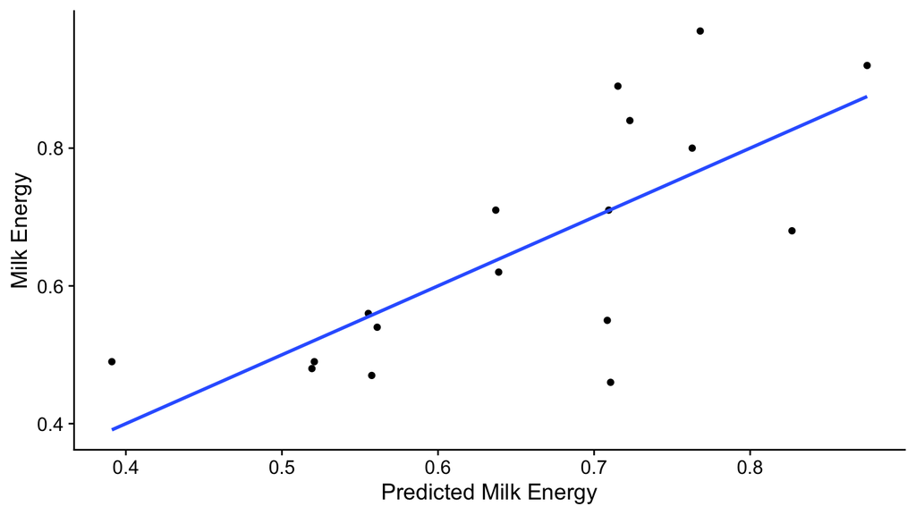

## \(R^{2}\): Multiple Regression Makes a Composite Variable

```r
cor(y_hat, M$Milk_Energy)^2
```

```
## [1] 0.5317037
```

```r
summary(fm_Multi)$r.squared
```

```
## [1] 0.5317037
```

## “Analysis of Variance”

Some total variability in *Y*:

1. Part explained by group membership
2. Part remains unexplained (“error” or “residual”)

\(F\)-statistic is the ratio of the two.

## Visualizing ANOVA

[figure not shown]

\[F = \frac{\mbox{Between Group Variation}}{\mbox{Within Group Variation}}\]

## Parts of an ANOVA table

```
## Analysis of Variance Table
##
## Response: Shift
##           Df Sum Sq Mean Sq F value   Pr(>F)
## Treatment  2 7.2245  3.6122  7.2894 0.004472 **
## Residuals 19 9.4153  0.4955
## ---
## Signif. codes:  0 '***' 0.001 '**' 0.01 '*' 0.05 '.' 0.1 ' ' 1
```

- `Sum Sq`: Variability accounted for by that part of the ANOVA
- `Mean Sq`: `Sum Sq` / `Df`
- `F value`: `Mean Sq` Treatment / `Mean Sq` Residual
- `Pr(>F)`: *P*-value for the *F*-test of that variable

## How much variation is explained by group membership: \(R^{2}\)?

```
## Analysis of Variance Table
##
## Response: Shift
##           Df Sum Sq Mean Sq F value   Pr(>F)
## Treatment  2 7.2245  3.6122  7.2894 0.004472 **
## Residuals 19 9.4153  0.4955
## ---
## Signif. codes:  0 '***' 0.001 '**' 0.01 '*' 0.05 '.' 0.1 ' ' 1
```

- `Sum Sq`: Variability accounted for by that part of the ANOVA
- `Mean Sq`: `Sum Sq` / `Df`
- `F value`: `Mean Sq` Treatment / `Mean Sq` Residual
- `Pr(>F)`: *P*-value for the *F*-test of that variable

## How much variation is explained by group membership: \(R^{2}\)?

\[R^{2} = \frac{\mbox{Variation accounted for by group membership}}{\mbox{Total variation}}\] \[R^{2} = \frac{\mbox{Sum Sq Group}}{\mbox{(Sum Sq Group + Sum Sq Residuals)}}\]

## How much variation is explained by group membership: \(R^{2}\)?

```
## Analysis of Variance Table
##
## Response: Shift
##           Df Sum Sq Mean Sq F value   Pr(>F)
## Treatment  2 7.2245  3.6122  7.2894 0.004472 **
## Residuals 19 9.4153  0.4955
## ---
## Signif. codes:  0 '***' 0.001 '**' 0.01 '*' 0.05 '.' 0.1 ' ' 1
```

```r
anova(fm_lm)$`Sum Sq`[1]/sum(anova(fm_lm)$`Sum Sq`)
```

```
## [1] 0.4341684
```

```r
7.224492/(7.224492 + 9.415345)
```

```
## [1] 0.4341684
```

## How much variation is explained by group membership: \(R^{2}\)?

```
##
## Call:
## lm(formula = Shift ~ Treatment, data = JL)
##
## Residuals:
##      Min       1Q   Median       3Q      Max
## -1.27857 -0.36125  0.03857  0.61147  1.06571
##
## Coefficients:
##               Estimate Std. Error t value Pr(>|t|)
## (Intercept)   -0.30875    0.24888  -1.241  0.22988
## Treatmenteyes -1.24268    0.36433  -3.411  0.00293 **
## Treatmentknee -0.02696    0.36433  -0.074  0.94178
## ---
## Signif. codes:  0 '***' 0.001 '**' 0.01 '*' 0.05 '.' 0.1 ' ' 1
##
## Residual standard error: 0.7039 on 19 degrees of freedom
## Multiple R-squared:  0.4342, Adjusted R-squared:  0.3746
## F-statistic: 7.289 on 2 and 19 DF,  p-value: 0.004472
```